# Heart Failure Research

Gianni Conde, Joshua Biggs-Bauer, Joaquin Rodarte

Winter 2022

# Goal

To determine the event of death due to heart failure based on clinical measurements utilizing supervised machine learning and data mining methods.

# About the Data

The data was retrieved from Kaggle and was originally collected from April to December of 2015 by the Allied Hospital in Faisalabad and the Faisalabad Institute of Cardiology, both residing in Punjab, Pakistan. The data contains patient medical information regarding heart failure with 299 patients (observations) and 13 clinical measurements (variables). These clinical measurements included age, anemia, creatinine phosphokinase (CPK), diabetes, ejection fraction, high blood pressure, platelets, serum creatinine, serum sodium, sex, smoking, time, and death event.

Link(s): https://www.kaggle.com/datasets/andrewmvd/heart-failure-clinical-data

# Role

My role in this analysis was to perform data cleansing and preparation, assist in creating exploratory visualizations, and to develop association rule mining models.

# Libaries

```r
library(arules)
```

```r
library(arulesViz)
library(caret)
library(corrplot)
library(DescTools)
library(directlabels)
library(dplyr)
library(e1071)
library(gbm)
library(ggplot2)
library(ggfortify)
library(ggthemes)
library(hrbrthemes)
library(ISLR)
library(kableExtra)
library(lightgbm)
library(mlr)
library(patchwork)
library(pROC)
library(randomForest)
library(randomForestExplainer)
library(ranger)
library(RColorBrewer)
library(reshape2)
library(rminer)
library(rpart)
library(rpart.plot)
library(rsample)
library(scales)
library(sjPlot)
library(skimr)
library(stats)
library(survminer)
library(survival)
library(tidyverse)
library(tree)
library(vip)
library(viridis)
```

# Loading the Data

```r
heartFailure <- read.csv("C:/Users/cassh/OneDrive/Desktop/Data Mining/Project/heart_failure_clinical_records_dataset.csv")
```

## Initial Inspecting of the Data

```r
dim(heartFailure)
```

```
## [1] 299  13
```

```r
view(heartFailure)
```

299 patients (observations), 13 clinical measurements (variables).

# Data Cleansing and Preparation

## Checking for missing values

```r
sum(is.na(heartFailure))
```

```
## [1] 0
```

0 missing values.

## Removing ‘time’ column and adding patient ‘id’ index

```r
heartFailure$time <- NULL
heartFailure <- tibble::rowid_to_column(heartFailure, "id")
str(heartFailure)
```

```
## 'data.frame':    299 obs. of  13 variables:
##  $ id                      : int  1 2 3 4 5 6 7 8 9 10 ...
##  $ age                     : num  75 55 65 50 65 90 75 60 65 80 ...
##  $ anaemia                 : int  0 0 0 1 1 1 1 1 0 1 ...
##  $ creatinine_phosphokinase: int  582 7861 146 111 160 47 246 315 157 123 ...
##  $ diabetes                : int  0 0 0 0 1 0 0 1 0 0 ...
##  $ ejection_fraction       : int  20 38 20 20 20 40 15 60 65 35 ...
##  $ high_blood_pressure     : int  1 0 0 0 0 1 0 0 0 1 ...
##  $ platelets               : num  265000 263358 162000 210000 327000 ...
##  $ serum_creatinine        : num  1.9 1.1 1.3 1.9 2.7 2.1 1.2 1.1 1.5 9.4 ...
##  $ serum_sodium            : int  130 136 129 137 116 132 137 131 138 133 ...
##  $ sex                     : int  1 1 1 1 0 1 1 1 0 1 ...
##  $ smoking                 : int  0 0 1 0 0 1 0 1 0 1 ...
##  $ DEATH_EVENT             : int  1 1 1 1 1 1 1 1 1 1 ...
```

```r
view(heartFailure)
```

After removing and adding the two variables, the remaining columns are either numeric or integers.

# Exploratory Data Analysis

## Observing numerical data

```r
numData <- heartFailure %>% select(1:2,4,6,8:10)
str(numData)
```

```
## 'data.frame':    299 obs. of  7 variables:
##  $ id                      : int  1 2 3 4 5 6 7 8 9 10 ...
##  $ age                     : num  75 55 65 50 65 90 75 60 65 80 ...
##  $ creatinine_phosphokinase: int  582 7861 146 111 160 47 246 315 157 123 ...
##  $ ejection_fraction       : int  20 38 20 20 20 40 15 60 65 35 ...
##  $ platelets               : num  265000 263358 162000 210000 327000 ...
##  $ serum_creatinine        : num  1.9 1.1 1.3 1.9 2.7 2.1 1.2 1.1 1.5 9.4 ...
##  $ serum_sodium            : int  130 136 129 137 116 132 137 131 138 133 ...
```

```r
dim(numData) # 299 patients, 7 clinical measures
```

```
## [1] 299   7
```

```r
colnames(numData)
```

```
## [1] "id"                       "age"
## [3] "creatinine_phosphokinase" "ejection_fraction"
## [5] "platelets"                "serum_creatinine"
## [7] "serum_sodium"
```

```r
view(numData)
summary(numData)
```

```
##        id             age        creatinine_phosphokinase ejection_fraction
##  Min.   :  1.0   Min.   :40.00   Min.   :  23.0           Min.   :14.00
##  1st Qu.: 75.5   1st Qu.:51.00   1st Qu.: 116.5           1st Qu.:30.00
##  Median :150.0   Median :60.00   Median : 250.0           Median :38.00
##  Mean   :150.0   Mean   :60.83   Mean   : 581.8           Mean   :38.08
##  3rd Qu.:224.5   3rd Qu.:70.00   3rd Qu.: 582.0           3rd Qu.:45.00
##  Max.   :299.0   Max.   :95.00   Max.   :7861.0           Max.   :80.00
##    platelets      serum_creatinine  serum_sodium
##  Min.   : 25100   Min.   :0.500    Min.   :113.0
##  1st Qu.:212500   1st Qu.:0.900    1st Qu.:134.0
##  Median :262000   Median :1.100    Median :137.0
##  Mean   :263358   Mean   :1.394    Mean   :136.6
##  3rd Qu.:303500   3rd Qu.:1.400    3rd Qu.:140.0
##  Max.   :850000   Max.   :9.400    Max.   :148.0
```

```r
view(summary(numData))
```

The newly created data frame features quantifiable measurements, except for ‘id’. This data frame includes 299 patients and 7 clinical measures.

## Observing binary data

```r
binaryData <- (heartFailure %>% select(3,5,7,11:13))
str(binaryData)
```

```
## 'data.frame':    299 obs. of  6 variables:
##  $ anaemia            : int  0 0 0 1 1 1 1 1 0 1 ...
##  $ diabetes           : int  0 0 0 0 1 0 0 1 0 0 ...
##  $ high_blood_pressure: int  1 0 0 0 0 1 0 0 0 1 ...
##  $ sex                : int  1 1 1 1 0 1 1 1 0 1 ...
##  $ smoking            : int  0 0 1 0 0 1 0 1 0 1 ...
##  $ DEATH_EVENT        : int  1 1 1 1 1 1 1 1 1 1 ...
```

```r
dim(binaryData)
```

```
## [1] 299   6
```

```r
colnames(binaryData)
```

```
## [1] "anaemia"             "diabetes"            "high_blood_pressure"
## [4] "sex"                 "smoking"             "DEATH_EVENT"
```

```r
view(binaryData)
```

The newly created data frame features qualitative measurements including 299 patients and 6 clinical measures.

```r
table(heartFailure$anaemia)
```

```
##
##   0   1
## 170 129
```

```r
table(heartFailure$diabetes)
```

```
##
##   0   1
## 174 125
```

```r
table(heartFailure$high_blood_pressure)
```

```
##
##   0   1
## 194 105
```

```r
table(heartFailure$sex)
```

```
##
##   0   1
## 105 194
```

```r
table(heartFailure$smoking)
```

```
##
##   0   1
## 203  96
```

```r
table(heartFailure$DEATH_EVENT)
```

```
##
##   0   1
## 203  96
```

105 patients had high blood pressure, while 194 did not. 105 of the patients were female, while 194 were male. Despite their identical ratios, it would not be wise to assume that they are correlated since it would be unlikely that all patients with high blood pressure were female.

## Plotting Distributions, Correlations, and Box Plots

### Anemia vs. Death Event

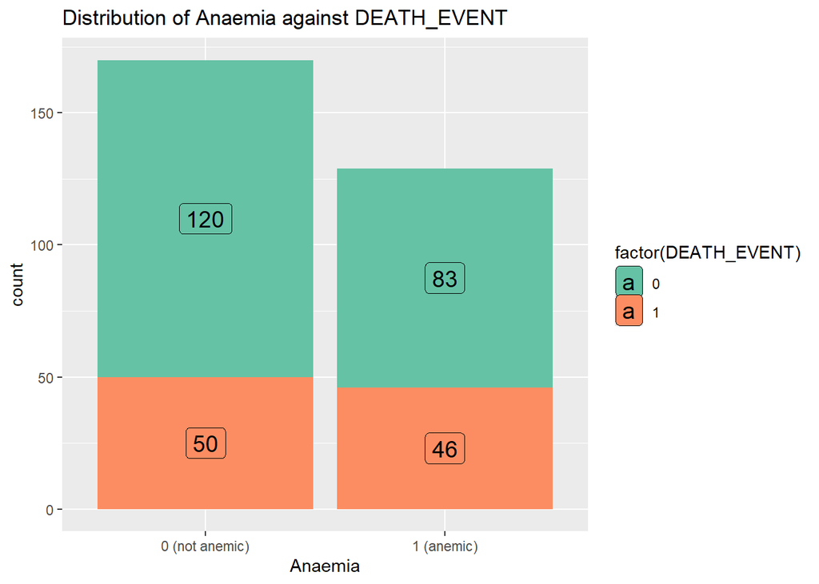

```r
ggplot(heartFailure, aes(x = factor(anaemia), fill = factor(DEATH_EVENT))) +
  geom_bar(stat = "count", position = "stack", show.legend = FALSE) +
  scale_x_discrete(labels  = c("0 (not anemic)", "1 (anemic)")) +
  scale_fill_brewer(palette = "Set2") +
  labs(x = "Anaemia") +
  labs(title = "Distribution of Anaemia against DEATH_EVENT") +
  geom_label(stat = "count", aes(label = ..count..), position = position_stack(vjust = 0.5),
             size = 5)
```

### Diabetes vs. Death Event

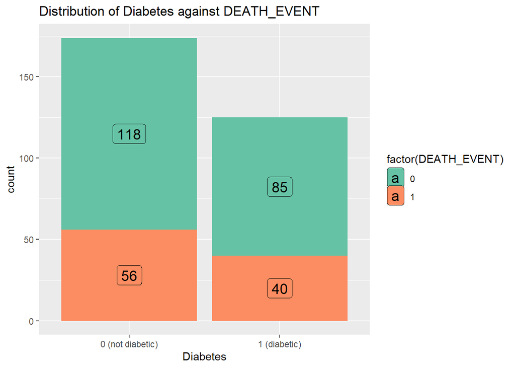

```r
ggplot(heartFailure, aes(x = factor(diabetes), fill = factor(DEATH_EVENT))) +
  geom_bar(stat = "count", position = "stack", show.legend = FALSE) +
  scale_x_discrete(labels  = c("0 (not diabetic)", "1 (diabetic)")) +
  scale_fill_brewer(palette = "Set2") +
  labs(x = "Diabetes") +
  labs(title = "Distribution of Diabetes against DEATH_EVENT") +
  geom_label(stat = "count", aes(label = ..count..), position = position_stack(vjust = 0.5),
             size = 5)
```

### High Blood Pressure vs. Death Event

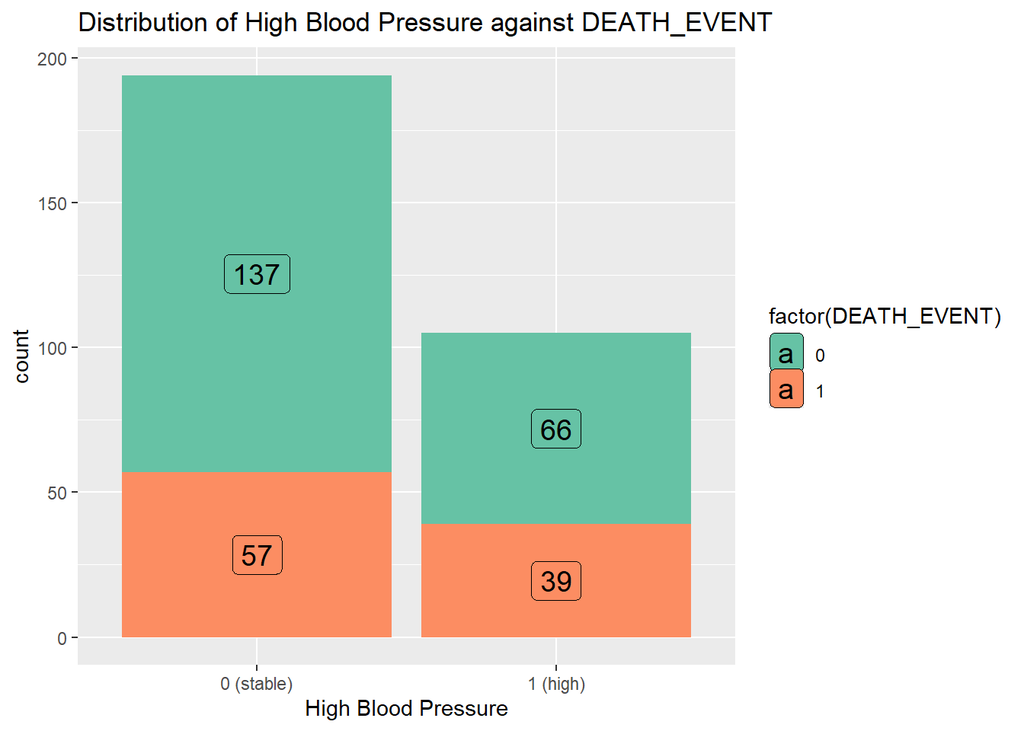

```r
ggplot(heartFailure, aes(x = factor(high_blood_pressure), fill = factor(DEATH_EVENT))) +
  geom_bar(stat = "count", position = "stack", show.legend = FALSE) +
  scale_x_discrete(labels  = c("0 (stable)", "1 (high)")) +
  scale_fill_brewer(palette = "Set2") +
  labs(x = "High Blood Pressure") +
  labs(title = "Distribution of High Blood Pressure against DEATH_EVENT") +
  geom_label(stat = "count", aes(label = ..count..), position = position_stack(vjust = 0.5),
             size = 5)
```

### Sex vs. Death Event

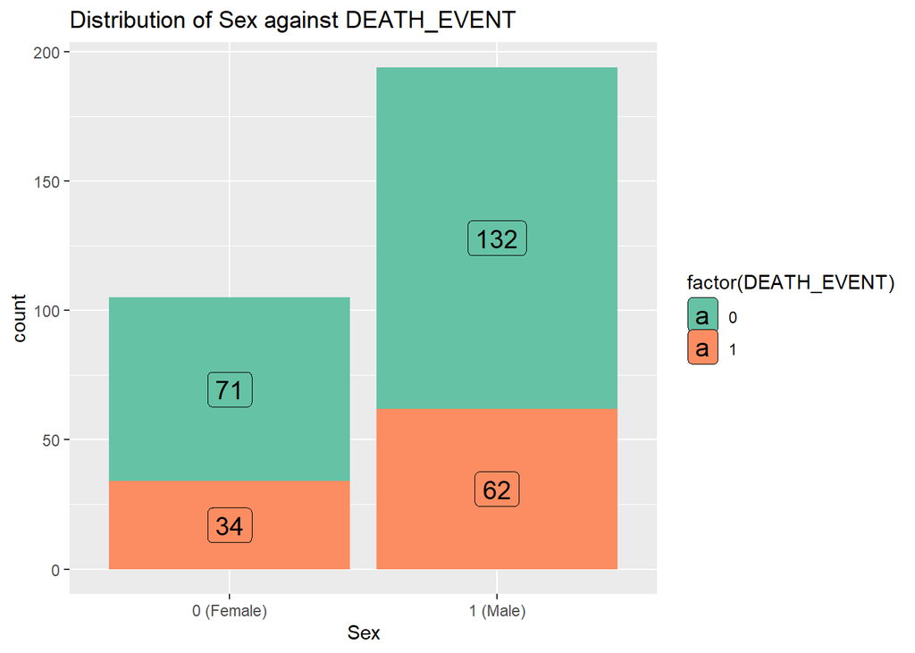

```r
ggplot(heartFailure, aes(x = factor(sex), fill = factor(DEATH_EVENT))) +
  geom_bar(stat = "count", position = "stack", show.legend = FALSE) +
  scale_x_discrete(labels  = c("0 (Female)", "1 (Male)")) +
  scale_fill_brewer(palette = "Set2") +
  labs(x = "Sex") +
  labs(title = "Distribution of Sex against DEATH_EVENT") +
  geom_label(stat = "count", aes(label = ..count..), position = position_stack(vjust = 0.5),
             size = 5)
```

### Smoking vs. Death Event

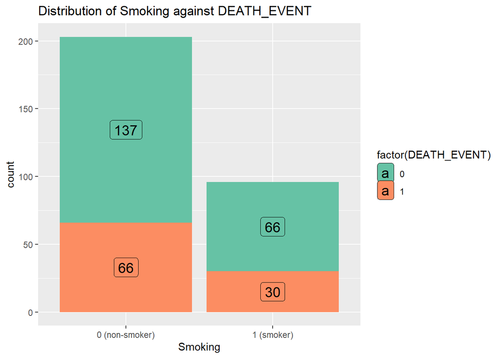

```r
ggplot(heartFailure, aes(x = factor(smoking), fill = factor(DEATH_EVENT))) +
  geom_bar(stat = "count", position = "stack", show.legend = FALSE) +
  scale_x_discrete(labels  = c("0 (non-smoker)", "1 (smoker)")) +
  scale_fill_brewer(palette = "Set2") +
  labs(x = "Smoking") +
  labs(title = "Distribution of Smoking against DEATH_EVENT") +
  geom_label(stat = "count", aes(label = ..count..), position = position_stack(vjust = 0.5),
             size = 5)
```

### Distribtuion of Age and Death Event

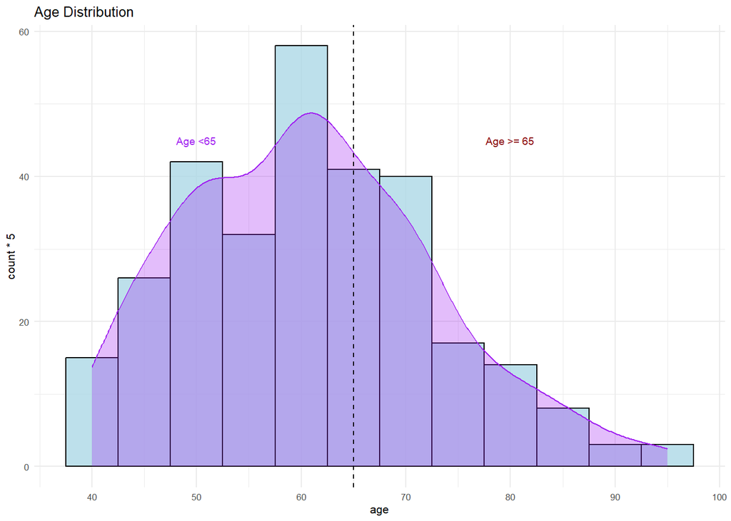

```r
Viz1 <-ggplot(heartFailure, aes(x=age)) +
  geom_histogram(binwidth = 5, colour="black", fill="lightblue", alpha=0.8) +
  geom_density(eval(bquote(aes(y=..count..*5))), colour="purple", fill="purple",
  alpha=0.3) + scale_x_continuous(breaks = seq(40,100,10)) +
  geom_vline(xintercept = 65, linetype="dashed") +
  annotate("text", x=50, y=45, label="Age <65", size=2.5, color="purple") +
  annotate("text", x=80, y=45, label="Age >= 65", size=2.5, color="dark red") +
  labs(title="Age Distribution") + theme_minimal(base_size = 8)
Viz1
```

### Serum Creatinine Distribution

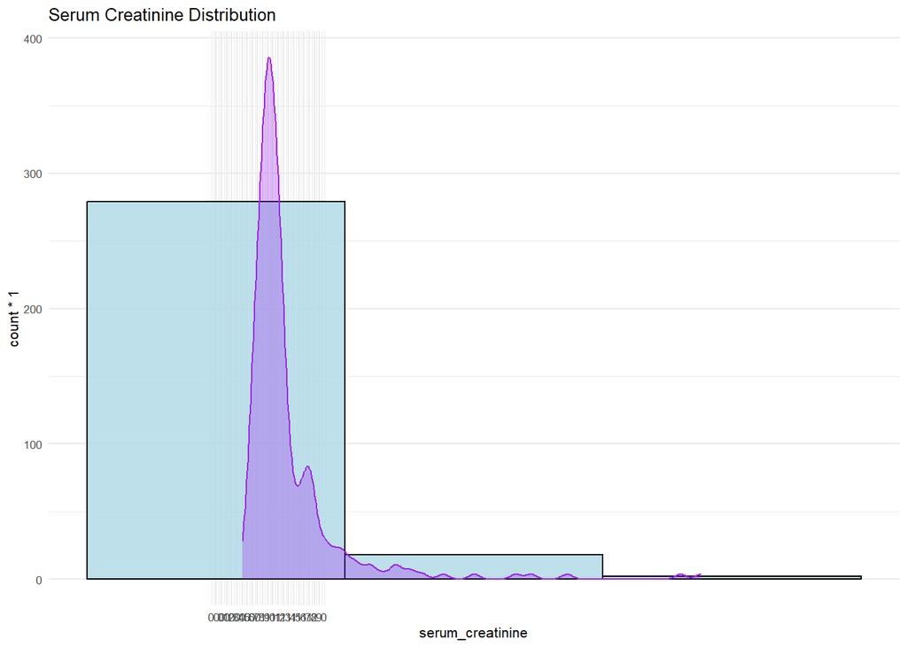

```r
Viz2 <- ggplot(heartFailure, aes(x=serum_creatinine)) +
  geom_histogram(binwidth = 5, colour="black", fill="lightblue", alpha=0.8) +
  geom_density(eval(bquote(aes(y=..count..*1))), colour="purple", fill="purple",
  alpha=0.3) + scale_x_continuous(breaks = seq(0,2,0.1)) +
  labs(title="Serum Creatinine Distribution") + theme_minimal(base_size = 8)
Viz2
```

### Correlation Plot

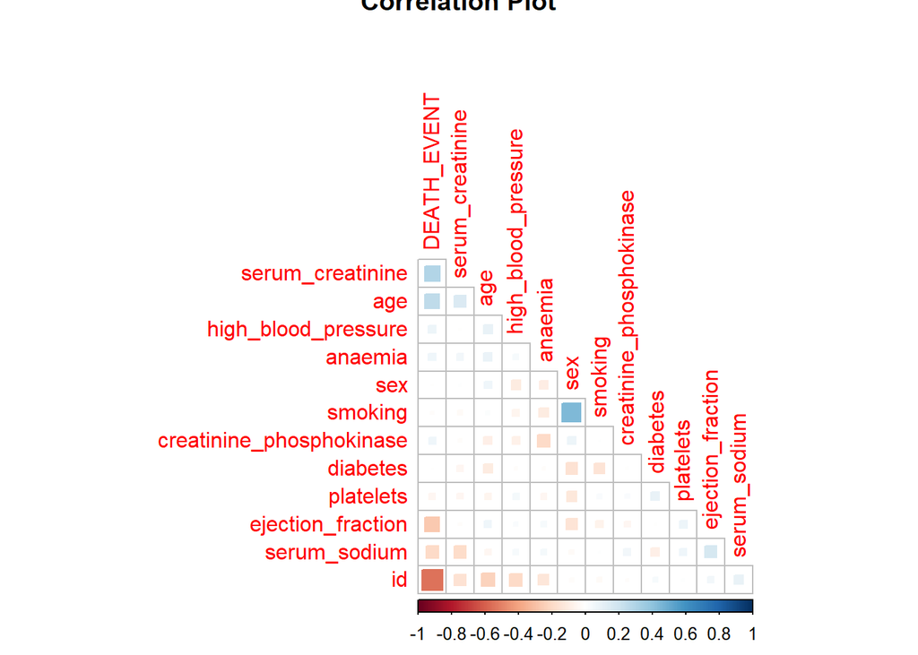

```r
C = cor(heartFailure)
corrplot(C, method = 'square', order = 'FPC',type = 'lower',
         diag = FALSE, main = 'Correlation Plot')
```

### Age and Death Event Box Plots

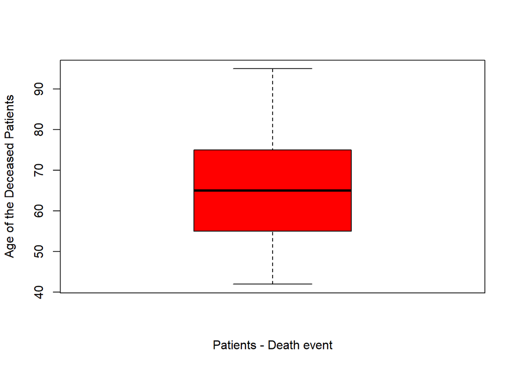

```r
hf_death <- filter(heartFailure,DEATH_EVENT==1)
hf_noDeath <- filter(heartFailure,DEATH_EVENT==0)

boxplot(hf_death$age,ylab="Age of the Deceased Patients" , xlab="Patients - Death event", col="red")
```

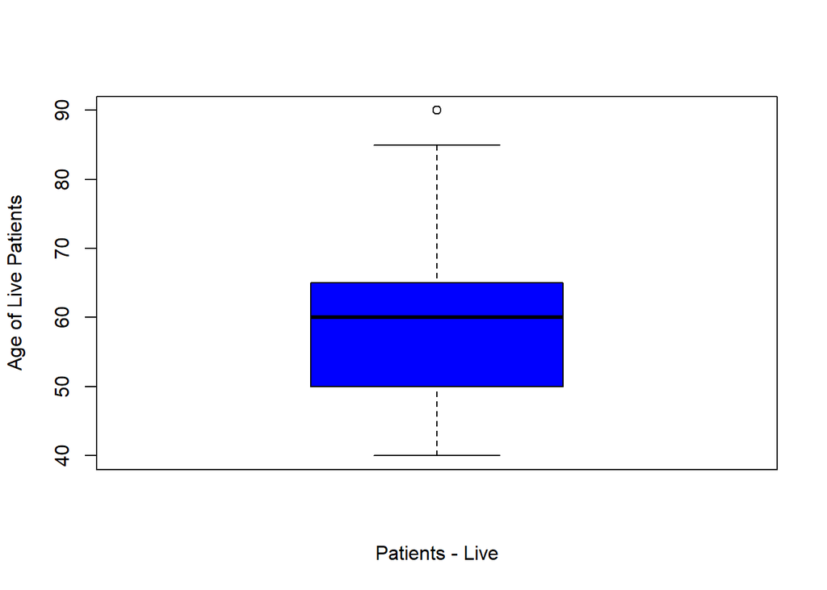

```
## [1] 90
```

```r
boxplot(hf_noDeath$age,ylab="Age of Live Patients" , xlab="Patients - Live", col="blue")$out
```

```r
summary(hf_death)
```

```
##        id              age           anaemia       creatinine_phosphokinase
##  Min.   :  1.00   Min.   :42.00   Min.   :0.0000   Min.   :  23.0
##  1st Qu.: 27.75   1st Qu.:55.00   1st Qu.:0.0000   1st Qu.: 128.8
##  Median : 54.50   Median :65.00   Median :0.0000   Median : 259.0
##  Mean   : 81.77   Mean   :65.22   Mean   :0.4792   Mean   : 670.2
##  3rd Qu.:130.50   3rd Qu.:75.00   3rd Qu.:1.0000   3rd Qu.: 582.0
##  Max.   :267.00   Max.   :95.00   Max.   :1.0000   Max.   :7861.0
##     diabetes      ejection_fraction high_blood_pressure   platelets
##  Min.   :0.0000   Min.   :14.00     Min.   :0.0000      Min.   : 47000
##  1st Qu.:0.0000   1st Qu.:25.00     1st Qu.:0.0000      1st Qu.:197500
##  Median :0.0000   Median :30.00     Median :0.0000      Median :258500
##  Mean   :0.4167   Mean   :33.47     Mean   :0.4062      Mean   :256381
##  3rd Qu.:1.0000   3rd Qu.:38.00     3rd Qu.:1.0000      3rd Qu.:311000
##  Max.   :1.0000   Max.   :70.00     Max.   :1.0000      Max.   :621000
##  serum_creatinine  serum_sodium        sex            smoking
##  Min.   :0.600    Min.   :116.0   Min.   :0.0000   Min.   :0.0000
##  1st Qu.:1.075    1st Qu.:133.0   1st Qu.:0.0000   1st Qu.:0.0000
##  Median :1.300    Median :135.5   Median :1.0000   Median :0.0000
##  Mean   :1.836    Mean   :135.4   Mean   :0.6458   Mean   :0.3125
##  3rd Qu.:1.900    3rd Qu.:138.2   3rd Qu.:1.0000   3rd Qu.:1.0000
##  Max.   :9.400    Max.   :146.0   Max.   :1.0000   Max.   :1.0000
##   DEATH_EVENT
##  Min.   :1
##  1st Qu.:1
##  Median :1
##  Mean   :1
##  3rd Qu.:1
##  Max.   :1
```

```r
summary(hf_noDeath)
```

```
##        id             age           anaemia       creatinine_phosphokinase
##  Min.   : 15.0   Min.   :40.00   Min.   :0.0000   Min.   :  30.0
##  1st Qu.:121.5   1st Qu.:50.00   1st Qu.:0.0000   1st Qu.: 109.0
##  Median :189.0   Median :60.00   Median :0.0000   Median : 245.0
##  Mean   :182.3   Mean   :58.76   Mean   :0.4089   Mean   : 540.1
##  3rd Qu.:245.5   3rd Qu.:65.00   3rd Qu.:1.0000   3rd Qu.: 582.0
##  Max.   :299.0   Max.   :90.00   Max.   :1.0000   Max.   :5209.0
##     diabetes      ejection_fraction high_blood_pressure   platelets
##  Min.   :0.0000   Min.   :17.00     Min.   :0.0000      Min.   : 25100
##  1st Qu.:0.0000   1st Qu.:35.00     1st Qu.:0.0000      1st Qu.:219500
##  Median :0.0000   Median :38.00     Median :0.0000      Median :263000
##  Mean   :0.4187   Mean   :40.27     Mean   :0.3251      Mean   :266658
##  3rd Qu.:1.0000   3rd Qu.:45.00     3rd Qu.:1.0000      3rd Qu.:302000
##  Max.   :1.0000   Max.   :80.00     Max.   :1.0000      Max.   :850000
##  serum_creatinine  serum_sodium        sex            smoking
##  Min.   :0.500    Min.   :113.0   Min.   :0.0000   Min.   :0.0000
##  1st Qu.:0.900    1st Qu.:135.5   1st Qu.:0.0000   1st Qu.:0.0000
##  Median :1.000    Median :137.0   Median :1.0000   Median :0.0000
##  Mean   :1.185    Mean   :137.2   Mean   :0.6502   Mean   :0.3251
##  3rd Qu.:1.200    3rd Qu.:140.0   3rd Qu.:1.0000   3rd Qu.:1.0000
##  Max.   :6.100    Max.   :148.0   Max.   :1.0000   Max.   :1.0000
##   DEATH_EVENT
##  Min.   :0
##  1st Qu.:0
##  Median :0
##  Mean   :0
##  3rd Qu.:0
##  Max.   :0
```

# Model Preparation

## 1st Data Split

```r
set.seed=9
trainTestSplit1 <- sample(2, nrow(heartFailure), replace=TRUE, prob=c(0.8,0.2))
train1 = heartFailure[trainTestSplit1==1,]
test1 = heartFailure[trainTestSplit1==2,]
dim(train1)
```

```
## [1] 233  13
```

```r
dim(test1)
```

```
## [1] 66 13
```

## 2nd Data Split

```r
set.seed=20
trainTestSplit2 <- sample(2, nrow(heartFailure), replace=TRUE, prob=c(0.7,0.3))
train2 = heartFailure[trainTestSplit2==1,]
test2 = heartFailure[trainTestSplit2==2,]
dim(train2)
```

```
## [1] 220  13
```

```r
dim(test2)
```

```
## [1] 79 13
```

## Drawing Confusion Matrix

```r
## Function for drawing confusion matrix
draw_confusion_matrix <- function(cm) {
  total <- sum(cm$table)
  res <- as.numeric(cm$table)
  # Set up the colors (and gradients) RColorBrewer.
  greenPalette <- c("#F7FCF5","#E5F5E0","#C7E9C0","#A1D99B","#74C476","#41AB5D","#238B45","#006D2C","#00441B")
  redPalette <- c("#FFF5F0","#FEE0D2","#FCBBA1","#FC9272","#FB6A4A","#EF3B2C","#CB181D","#A50F15","#67000D")
  getColor <- function (greenOrRed = "green", amount = 0) {
    if (amount == 0)
      return("#FFFFFF")
    palette <- greenPalette
    if (greenOrRed == "red")
      palette <- redPalette
    colorRampPalette(palette)(100)[10 + ceiling(90 * amount / total)]
  }
  # CM Layout
  layout(matrix(c(1,1,2)))
  par(mar=c(2,2,2,2))
  plot(c(100, 345), c(300, 450), type = "n", xlab="", ylab="", xaxt='n', yaxt='n')
  title('CONFUSION MATRIX', cex.main=2)
  # The Matrix
  classes = colnames(cm$table)
  rect(150, 430, 240, 370, col=getColor("green", res[1]))
  text(195, 435, classes[1], cex=1.2)
  rect(250, 430, 340, 370, col=getColor("red", res[3]))
  text(295, 435, classes[2], cex=1.2)
  text(125, 370, 'Predicted', cex=1.3, srt=90, font=2)
  text(245, 450, 'Actual', cex=1.3, font=2)
  rect(150, 305, 240, 365, col=getColor("red", res[2]))
  rect(250, 305, 340, 365, col=getColor("green", res[4]))
  text(140, 400, classes[1], cex=1.2, srt=90)
  text(140, 335, classes[2], cex=1.2, srt=90)
  # Show the results
  text(195, 400, res[1], cex=1.6, font=2, col='white')
  text(195, 335, res[2], cex=1.6, font=2, col='white')
  text(295, 400, res[3], cex=1.6, font=2, col='white')
  text(295, 335, res[4], cex=1.6, font=2, col='white')
  # specifics, specifics, and more specifics
  plot(c(100, 0), c(100, 0), type = "n", xlab="", ylab="", main = "DETAILS", xaxt='n', yaxt='n')
  text(10, 85, names(cm$byClass[1]), cex=1.2, font=2)
  text(10, 70, round(as.numeric(cm$byClass[1]), 3), cex=1.2)
  text(30, 85, names(cm$byClass[2]), cex=1.2, font=2)
  text(30, 70, round(as.numeric(cm$byClass[2]), 3), cex=1.2)
  text(50, 85, names(cm$byClass[5]), cex=1.2, font=2)
  text(50, 70, round(as.numeric(cm$byClass[5]), 3), cex=1.2)
  text(70, 85, names(cm$byClass[6]), cex=1.2, font=2)
  text(70, 70, round(as.numeric(cm$byClass[6]), 3), cex=1.2)
  text(90, 85, names(cm$byClass[7]), cex=1.2, font=2)
  text(90, 70, round(as.numeric(cm$byClass[7]), 3), cex=1.2)
  # How accurate were we
  text(30, 35, names(cm$overall[1]), cex=1.5, font=2)
  text(30, 20, round(as.numeric(cm$overall[1]), 3), cex=1.4)
  text(70, 35, names(cm$overall[2]), cex=1.5, font=2)
  text(70, 20, round(as.numeric(cm$overall[2]), 3), cex=1.4)
  }
```

# Random Forest

## 1st Attempt

```r
rforest<- randomForest(factor(DEATH_EVENT) ~. , data=train1, ntree=1000, importance=TRUE)
summary(rforest)
```

```
##                 Length Class  Mode
## call               5   -none- call
## type               1   -none- character
## predicted        233   factor numeric
## err.rate        3000   -none- numeric
## confusion          6   -none- numeric
## votes            466   matrix numeric
## oob.times        233   -none- numeric
## classes            2   -none- character
## importance        48   -none- numeric
## importanceSD      36   -none- numeric
## localImportance    0   -none- NULL
## proximity          0   -none- NULL
## ntree              1   -none- numeric
## mtry               1   -none- numeric
## forest            14   -none- list
## y                233   factor numeric
## test               0   -none- NULL
## inbag              0   -none- NULL
## terms              3   terms  call
```

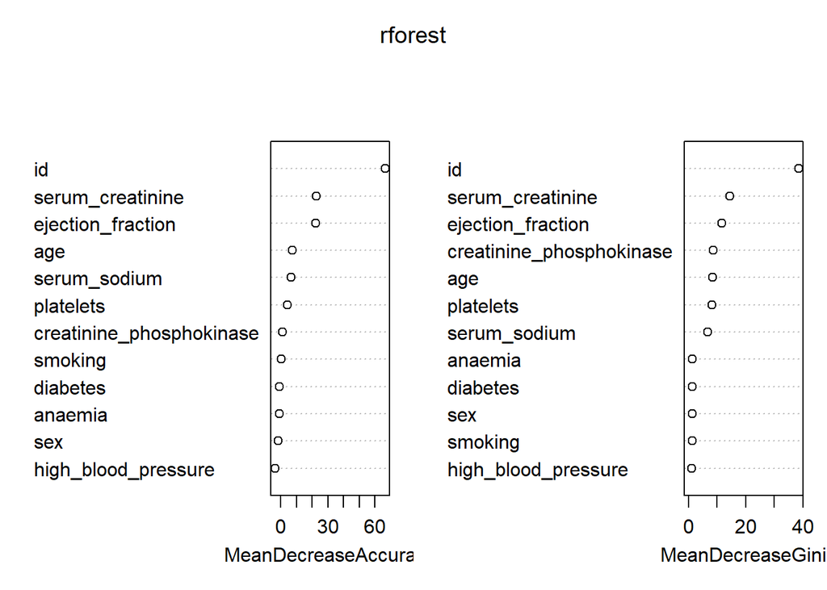

```r
imp <- varImp(rforest)
varImpPlot(rforest)
```

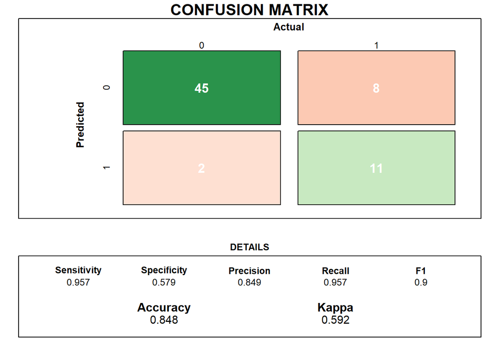

```r
# Predict the 1st random forest
rpredict <- predict(rforest, test1, type="class")
cm1 <- confusionMatrix(rpredict, as.factor(test1$DEATH_EVENT))
draw_confusion_matrix(cm1)
```

## 2nd Attempt

```r
moreTrees <- randomForest(factor(DEATH_EVENT) ~. , data=train2, ntree=1000, importance=TRUE)
summary(moreTrees)
```

```
##                 Length Class  Mode
## call               5   -none- call
## type               1   -none- character
## predicted        220   factor numeric
## err.rate        3000   -none- numeric
## confusion          6   -none- numeric
## votes            440   matrix numeric
## oob.times        220   -none- numeric
## classes            2   -none- character
## importance        48   -none- numeric
## importanceSD      36   -none- numeric
## localImportance    0   -none- NULL
## proximity          0   -none- NULL
## ntree              1   -none- numeric
## mtry               1   -none- numeric
## forest            14   -none- list
## y                220   factor numeric
## test               0   -none- NULL
## inbag              0   -none- NULL
## terms              3   terms  call
```

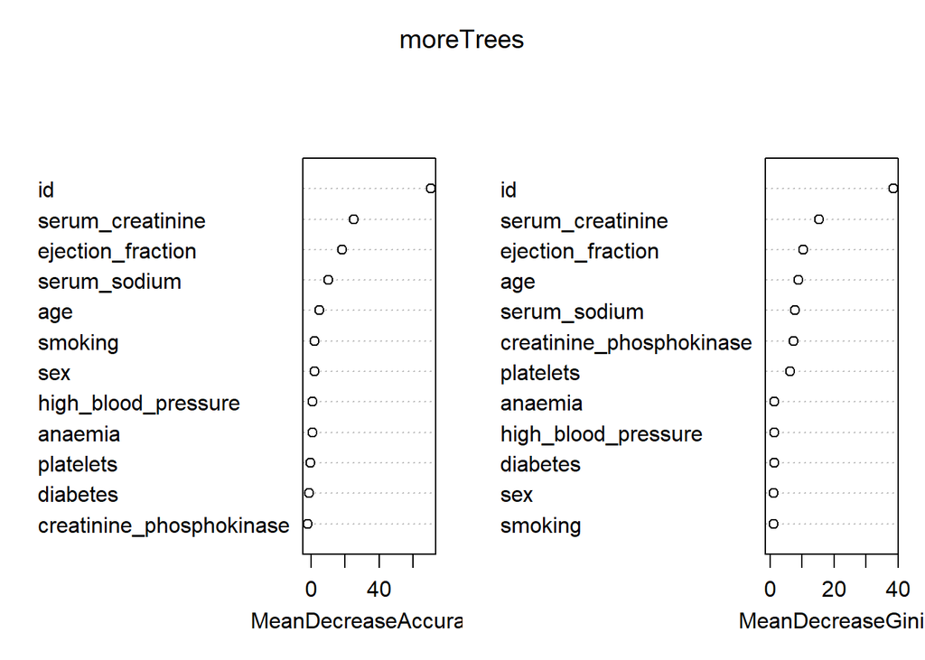

```r
imp <- varImp(moreTrees)
varImpPlot(moreTrees)
```

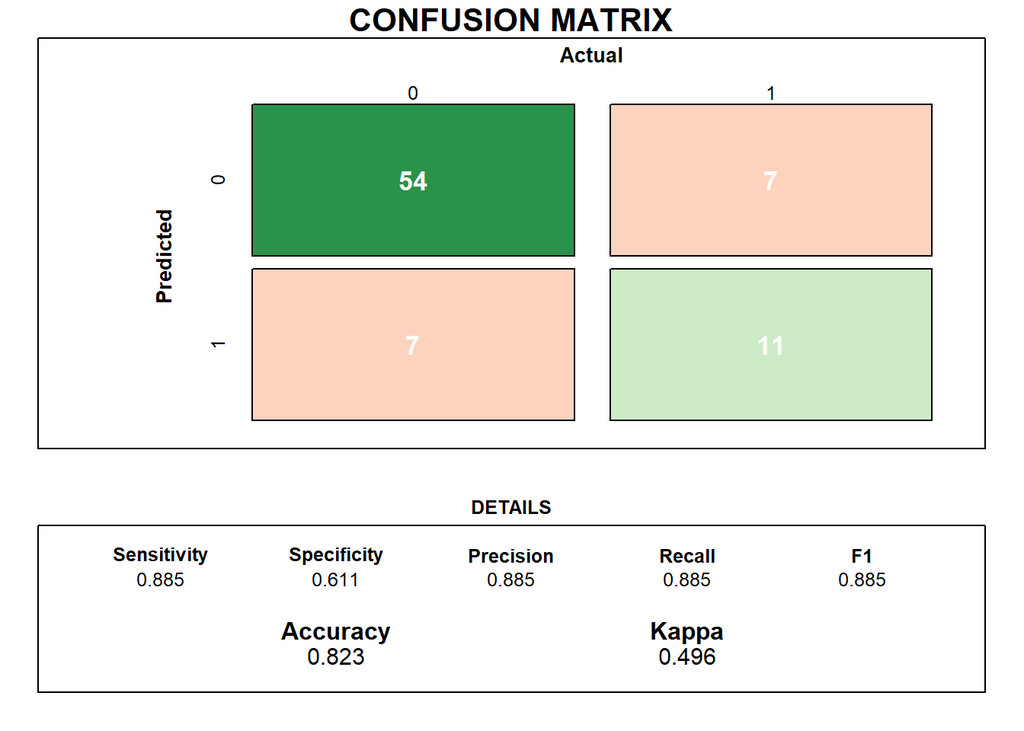

```r
# Predict the 2nd random forest
treePredict <- predict(moreTrees, test2, type="class")
cm2 <- confusionMatrix(treePredict, as.factor(test2$DEATH_EVENT))
draw_confusion_matrix(cm2)
```

# Support Vector Machine (SVM)

## 1st Attempt

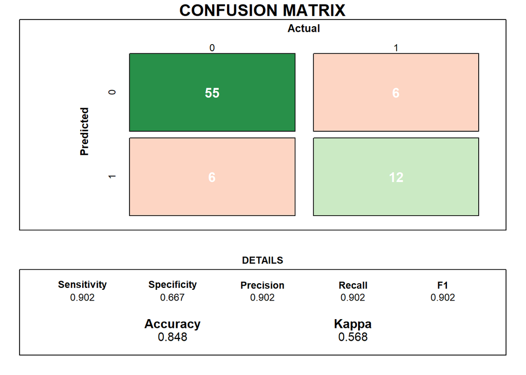

```r
svmmodel <- svm(formula=DEATH_EVENT~., data=train1, type="C-classification", kernel="linear")
# prediction
pred = predict(svmmodel, newdata=test2)
# Confusion matrix
cm3 <- confusionMatrix(pred, as.factor(test2$DEATH_EVENT))
draw_confusion_matrix(cm3)
```

## 2nd Attempt

```r
# tune SVM
tune <- tune.svm(x=train1[-3],y=train1[3], cost = seq( 0.2,0.3, 1))
tune$best.parameters
```

```
##   cost
## 1  0.2
```

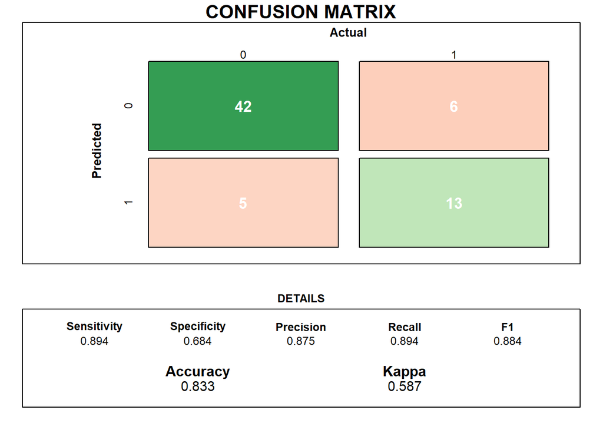

```r
# SVM model
svmmodel2 <-svm(formula=DEATH_EVENT~., data=train1, type="nu-classification", kernel="linear", cost=0.2)
pred = predict(svmmodel2, newdata=test1)
# confusion matrix
cm4 <- confusionMatrix(pred, as.factor(test1$DEATH_EVENT))
draw_confusion_matrix(cm4)
```

The two SVM models provided solid results, with the 1st being slightly superior. However, the 1st Random Forest model yielded the best results thus far.

# Decision Tree

## Model Preparation

```r
hf_DT <- subset(heartFailure,select=-c(id, age, platelets, serum_sodium,
                            creatinine_phosphokinase))
str(hf_DT)
```

```
## 'data.frame':    299 obs. of  8 variables:
##  $ anaemia            : int  0 0 0 1 1 1 1 1 0 1 ...
##  $ diabetes           : int  0 0 0 0 1 0 0 1 0 0 ...
##  $ ejection_fraction  : int  20 38 20 20 20 40 15 60 65 35 ...
##  $ high_blood_pressure: int  1 0 0 0 0 1 0 0 0 1 ...
##  $ serum_creatinine   : num  1.9 1.1 1.3 1.9 2.7 2.1 1.2 1.1 1.5 9.4 ...
##  $ sex                : int  1 1 1 1 0 1 1 1 0 1 ...
##  $ smoking            : int  0 0 1 0 0 1 0 1 0 1 ...
##  $ DEATH_EVENT        : int  1 1 1 1 1 1 1 1 1 1 ...
```

## Data Splitting: 1st Attempt

```r
set.seed(1)
train1 <- sample(1:nrow(hf_DT),209)
hf_train1 <- hf_DT[train1,]
hf_test1 <- hf_DT[-train1,]
dim(hf_train1)
```

```
## [1] 209   8
```

```r
dim(hf_test1)
```

```
## [1] 90  8
```

## Data Splitting: 2nd Attempt

```r
# 2nd split
set.seed(1)
train2 <- sample(1:nrow(hf_DT),209)
hf_train2 <- hf_DT[train2,]
hf_test2 <- hf_DT[-train2,]
```

## Data Splitting: 3rd Attempt

```r
# 3rd split
set.seed(1)
train3 <- sample(1:nrow(hf_DT),209)
hf_train3 <- hf_DT[train3,]
hf_test3 <- hf_DT[-train3,]
```

## Data Splitting: 4th Attempt

```r
# 4th split
set.seed(1)
train4 <- sample(1:nrow(hf_DT),209)
hf_train4 <- hf_DT[train4,]
hf_test4 <- hf_DT[-train4,]
```

##Tree Models

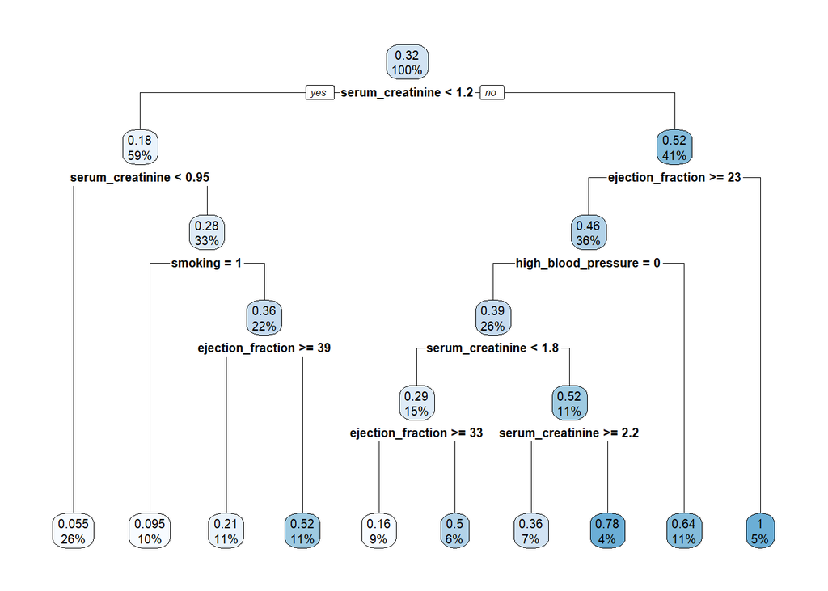

```r
#tree models
tree_model1 <- rpart(DEATH_EVENT~.,data=hf_train1)
tree_model2 <- rpart(DEATH_EVENT~.,data=hf_train2)
tree_model3 <- rpart(DEATH_EVENT~.,data=hf_train3)
tree_model4 <- rpart(DEATH_EVENT~.,data=hf_train4)
rpart.plot(tree_model1)
rpart.plot(tree_model2)
```

[output not shown]

```r
rpart.plot(tree_model3)
rpart.plot(tree_model4)
```

[output not shown]

## Model Fitting with Complexity Parameter vs. Cross-Validated Error

```r
cfit1 <- rpart(DEATH_EVENT~.,data=hf_train1, method='class')
cfit2 <- rpart(DEATH_EVENT~.,data=hf_train2, method='class')
cfit3 <- rpart(DEATH_EVENT~.,data=hf_train3, method='class')
cfit4 <- rpart(DEATH_EVENT~.,data=hf_train4, method='class')

model <- rpart(DEATH_EVENT~.,data=hf_train1, minsplit = 10, cp = 0.01)
str(model$cptable)
```

```
##  num [1:11, 1:5] 0.1319 0.0565 0.0338 0.0261 0.024 ...
##  - attr(*, "dimnames")=List of 2
##   ..$ : chr [1:11] "1" "2" "3" "4" ...
##   ..$ : chr [1:5] "CP" "nsplit" "rel error" "xerror" ...
```

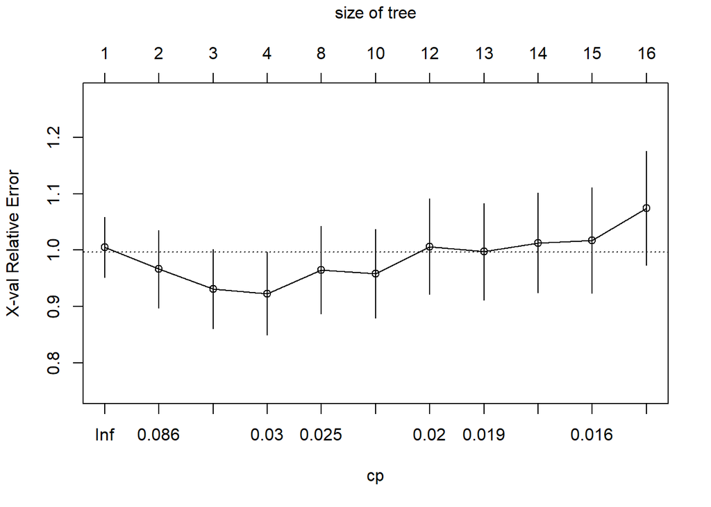

```r
plotcp(model)
```

## Optimal Complexity Parameter Value

```r
optimal_cp <- model$cptable[which.min(model$cptable[, "xerror"]), "CP"]
str(optimal_cp)
```

```
##  num 0.0261
```

```r
print(optimal_cp)
```

```
## [1] 0.02610471
```

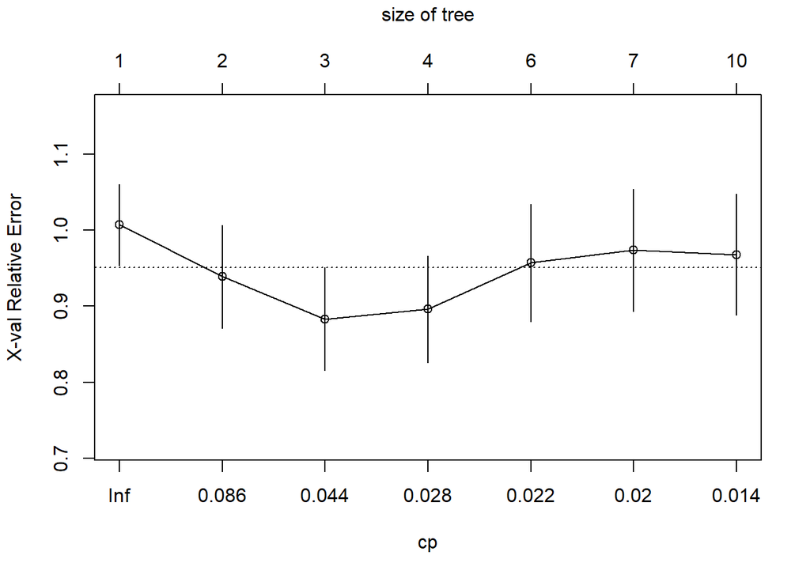

```r
plotcp(tree_model1)
```

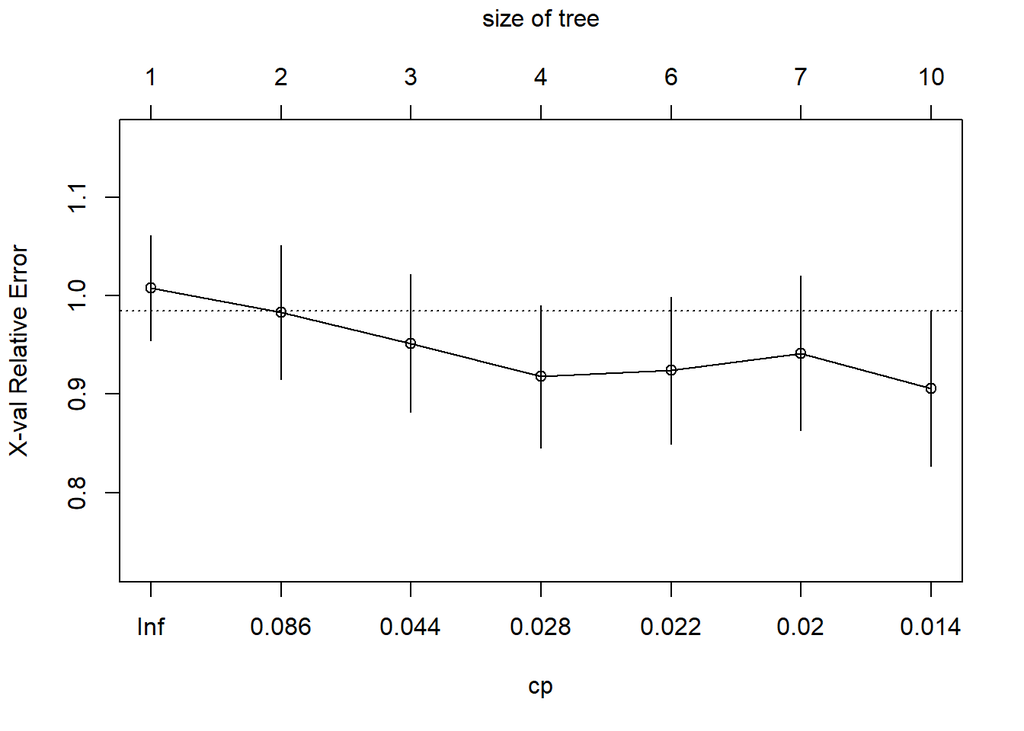

```r
plotcp(tree_model2)
```

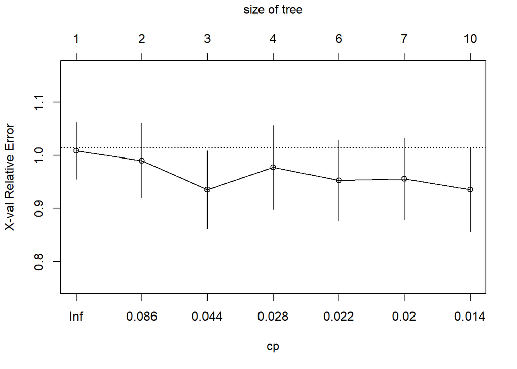

```r
plotcp(tree_model3)
```

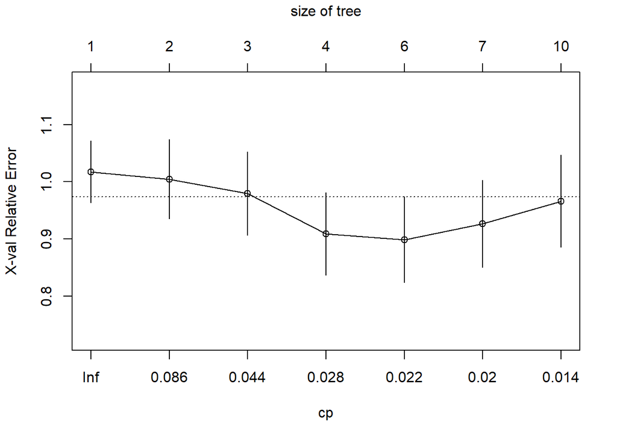

```r
plotcp(tree_model4)
```

## Final Decision Tree Model

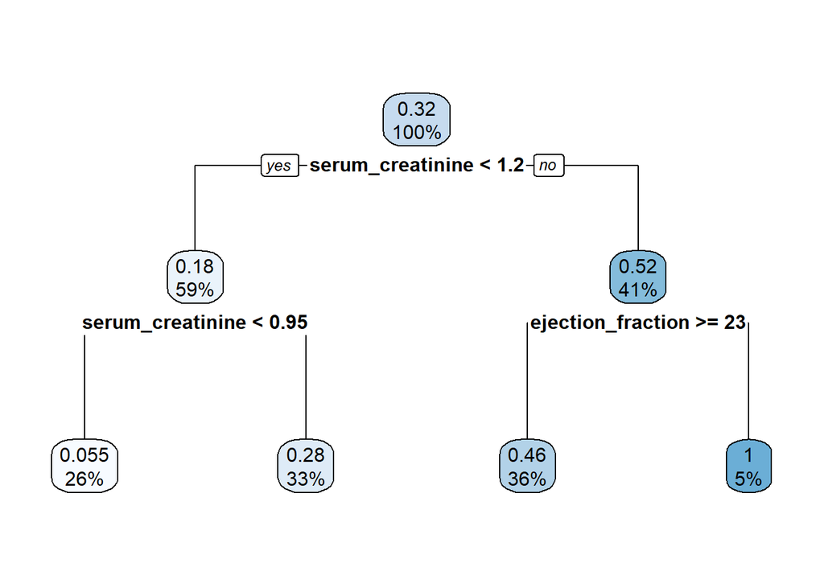

```r
final_model <- rpart(DEATH_EVENT~., data = hf_train1, minsplit = 10, cp = optimal_cp)
rpart.plot(final_model)
```

# Association Rule Mining

## Model Preparation

```r
# Replace binary values with generic naming schemes.
binaryData["anaemia"][binaryData["anaemia"] == "0"] <- "not anaemic"
binaryData["anaemia"][binaryData["anaemia"] == "1"] <- "anaemic"
binaryData["diabetes"][binaryData["diabetes"] == "0"] <- "not diabetic"
binaryData["diabetes"][binaryData["diabetes"] == "1"] <- "diabetic"
binaryData["high_blood_pressure"][binaryData["high_blood_pressure"] == "0"] <- "stable blood pressure"
binaryData["high_blood_pressure"][binaryData["high_blood_pressure"] == "1"] <- "high blood pressure"
binaryData["sex"][binaryData["sex"] == "0"] <- "female"
binaryData["sex"][binaryData["sex"] == "1"] <- "male"
binaryData["smoking"][binaryData["smoking"] == "0"] <- "non-smoker"
binaryData["smoking"][binaryData["smoking"] == "1"] <- "smoker"
binaryData["DEATH_EVENT"][binaryData["DEATH_EVENT"] == "0"] <- "survived"
binaryData["DEATH_EVENT"][binaryData["DEATH_EVENT"] == "1"] <- "died"
head(binaryData,299) %>%
  DT::datatable()
```

|  | anaemia | diabetes | high_blood_pressure | sex | smoking | DEATH_EVENT |
| --- | --- | --- | --- | --- | --- | --- |
| 1 | not anaemic | not diabetic | high blood pressure | male | non-smoker | died |
| 2 | not anaemic | not diabetic | stable blood pressure | male | non-smoker | died |
| 3 | not anaemic | not diabetic | stable blood pressure | male | smoker | died |
| 4 | anaemic | not diabetic | stable blood pressure | male | non-smoker | died |
| 5 | anaemic | diabetic | stable blood pressure | female | non-smoker | died |
| 6 | anaemic | not diabetic | high blood pressure | male | smoker | died |
| 7 | anaemic | not diabetic | stable blood pressure | male | non-smoker | died |
| 8 | anaemic | diabetic | stable blood pressure | male | smoker | died |
| 9 | not anaemic | not diabetic | stable blood pressure | female | non-smoker | died |
| 10 | anaemic | not diabetic | high blood pressure | male | smoker | died |

[output cut: 289 more lines]

```r
view(binaryData)
```

## 1st Attempt

```r
rules <- apriori(binaryData, parameter = list(supp = 0.001, conf = 0.9))
```

```
## Apriori
##
## Parameter specification:
##  confidence minval smax arem  aval originalSupport maxtime support minlen
##         0.9    0.1    1 none FALSE            TRUE       5   0.001      1
##  maxlen target  ext
##      10  rules TRUE
##
## Algorithmic control:
##  filter tree heap memopt load sort verbose
##     0.1 TRUE TRUE  FALSE TRUE    2    TRUE
##
## Absolute minimum support count: 0
##
## set item appearances ...[0 item(s)] done [0.00s].
## set transactions ...[12 item(s), 299 transaction(s)] done [0.00s].
## sorting and recoding items ... [12 item(s)] done [0.00s].
## creating transaction tree ... done [0.00s].
## checking subsets of size 1 2 3 4 5 6 done [0.00s].
## writing ... [202 rule(s)] done [0.00s].
## creating S4 object  ... done [0.00s].
```

```r
summary(rules)
```

```
## set of 202 rules
##
## rule length distribution (lhs + rhs):sizes
##  2  3  4  5  6
##  2 16 51 85 48
##
##    Min. 1st Qu.  Median    Mean 3rd Qu.    Max.
##   2.000   4.000   5.000   4.797   5.000   6.000
##
## summary of quality measures:
##     support           confidence        coverage             lift
##  Min.   :0.003344   Min.   :0.9000   Min.   :0.003344   Min.   :1.326
##  1st Qu.:0.006689   1st Qu.:0.9661   1st Qu.:0.006689   1st Qu.:1.457
##  Median :0.030100   Median :1.0000   Median :0.033445   Median :1.508
##  Mean   :0.049654   Mean   :0.9816   Mean   :0.051144   Mean   :1.753
##  3rd Qu.:0.069398   3rd Qu.:1.0000   3rd Qu.:0.072743   3rd Qu.:1.718
##  Max.   :0.337793   Max.   :1.0000   Max.   :0.351171   Max.   :3.115
##      count
##  Min.   :  1.00
##  1st Qu.:  2.00
##  Median :  9.00
##  Mean   : 14.85
##  3rd Qu.: 20.75
##  Max.   :101.00
##
## mining info:
##        data ntransactions support confidence
##  binaryData           299   0.001        0.9
##                                                                    call
##  apriori(data = binaryData, parameter = list(supp = 0.001, conf = 0.9))
```

Using the Apriori algorithm, we want about 20-30 generated rules. This 1st attempt generated 202 rules, so parameter adjustment will be made.

## 2nd Attempt

```r
rules2 <- apriori(binaryData, parameter = list(supp = 0.1, conf = 0.9))
```

```
## Apriori
##
## Parameter specification:
##  confidence minval smax arem  aval originalSupport maxtime support minlen
##         0.9    0.1    1 none FALSE            TRUE       5     0.1      1
##  maxlen target  ext
##      10  rules TRUE
##
## Algorithmic control:
##  filter tree heap memopt load sort verbose
##     0.1 TRUE TRUE  FALSE TRUE    2    TRUE
##
## Absolute minimum support count: 29
##
## set item appearances ...[0 item(s)] done [0.00s].
## set transactions ...[12 item(s), 299 transaction(s)] done [0.00s].
## sorting and recoding items ... [12 item(s)] done [0.00s].
## creating transaction tree ... done [0.00s].
## checking subsets of size 1 2 3 4 5 done [0.00s].
## writing ... [32 rule(s)] done [0.00s].
## creating S4 object  ... done [0.00s].
```

```r
summary(rules2)
```

```
## set of 32 rules
##
## rule length distribution (lhs + rhs):sizes
##  2  3  4  5
##  2 13 13  4
##
##    Min. 1st Qu.  Median    Mean 3rd Qu.    Max.
##   2.000   3.000   4.000   3.594   4.000   5.000
##
## summary of quality measures:
##     support         confidence        coverage           lift
##  Min.   :0.1037   Min.   :0.9118   Min.   :0.1070   Min.   :1.343
##  1st Qu.:0.1162   1st Qu.:0.9633   1st Qu.:0.1162   1st Qu.:1.431
##  Median :0.1472   Median :0.9764   Median :0.1472   Median :1.473
##  Mean   :0.1606   Mean   :0.9764   Mean   :0.1647   Mean   :1.472
##  3rd Qu.:0.1831   3rd Qu.:1.0000   3rd Qu.:0.1890   3rd Qu.:1.511
##  Max.   :0.3378   Max.   :1.0000   Max.   :0.3512   Max.   :1.541
##      count
##  Min.   : 31.00
##  1st Qu.: 34.75
##  Median : 44.00
##  Mean   : 48.03
##  3rd Qu.: 54.75
##  Max.   :101.00
##
## mining info:
##        data ntransactions support confidence
##  binaryData           299     0.1        0.9
##                                                                  call
##  apriori(data = binaryData, parameter = list(supp = 0.1, conf = 0.9))
```

After increasing the support parameter, 32 rules were generated, which is slightly above our threshold. So, parameters will be adjusted again.

## 3rd Attempt

```r
rules3 <- apriori(binaryData, parameter = list(supp = 0.13, conf = 0.9))
```

```
## Apriori
##
## Parameter specification:
##  confidence minval smax arem  aval originalSupport maxtime support minlen
##         0.9    0.1    1 none FALSE            TRUE       5    0.13      1
##  maxlen target  ext
##      10  rules TRUE
##
## Algorithmic control:
##  filter tree heap memopt load sort verbose
##     0.1 TRUE TRUE  FALSE TRUE    2    TRUE
##
## Absolute minimum support count: 38
##
## set item appearances ...[0 item(s)] done [0.00s].
## set transactions ...[12 item(s), 299 transaction(s)] done [0.00s].
## sorting and recoding items ... [12 item(s)] done [0.00s].
## creating transaction tree ... done [0.00s].
## checking subsets of size 1 2 3 4 5 done [0.00s].
## writing ... [20 rule(s)] done [0.00s].
## creating S4 object  ... done [0.00s].
```

```r
summary(rules3)
```

```
## set of 20 rules
##
## rule length distribution (lhs + rhs):sizes
##  2  3  4
##  2 11  7
##
##    Min. 1st Qu.  Median    Mean 3rd Qu.    Max.
##    2.00    3.00    3.00    3.25    4.00    4.00
##
## summary of quality measures:
##     support         confidence        coverage           lift
##  Min.   :0.1338   Min.   :0.9318   Min.   :0.1371   Min.   :1.372
##  1st Qu.:0.1547   1st Qu.:0.9622   1st Qu.:0.1547   1st Qu.:1.419
##  Median :0.1689   Median :0.9764   Median :0.1756   Median :1.484
##  Mean   :0.1898   Mean   :0.9754   Mean   :0.1948   Mean   :1.474
##  3rd Qu.:0.2149   3rd Qu.:0.9851   3rd Qu.:0.2207   3rd Qu.:1.511
##  Max.   :0.3378   Max.   :1.0000   Max.   :0.3512   Max.   :1.541
##      count
##  Min.   : 40.00
##  1st Qu.: 46.25
##  Median : 50.50
##  Mean   : 56.75
##  3rd Qu.: 64.25
##  Max.   :101.00
##
## mining info:
##        data ntransactions support confidence
##  binaryData           299    0.13        0.9
##                                                                   call
##  apriori(data = binaryData, parameter = list(supp = 0.13, conf = 0.9))
```

```r
inspect(rules3)
```

```
##      lhs                                             rhs                    support confidence  coverage     lift count
## [1]  {smoking=smoker}                             => {sex=male}           0.3076923  0.9583333 0.3210702 1.477019    92
## [2]  {sex=female}                                 => {smoking=non-smoker} 0.3377926  0.9619048 0.3511706 1.416796   101
## [3]  {anaemia=not anaemic,
##       smoking=smoker}                             => {sex=male}           0.2006689  0.9677419 0.2073579 1.491520    60
## [4]  {diabetes=not diabetic,
##       smoking=smoker}                             => {sex=male}           0.2140468  0.9696970 0.2207358 1.494533    64
## [5]  {high_blood_pressure=stable blood pressure,
##       smoking=smoker}                             => {sex=male}           0.2173913  0.9848485 0.2207358 1.517885    65
## [6]  {smoking=smoker,
##       DEATH_EVENT=survived}                       => {sex=male}           0.2173913  0.9848485 0.2207358 1.517885    65
## [7]  {high_blood_pressure=high blood pressure,
##       sex=female}                                 => {smoking=non-smoker} 0.1371237  0.9318182 0.1471572 1.372481    41
## [8]  {diabetes=diabetic,
##       sex=female}                                 => {smoking=non-smoker} 0.1772575  0.9636364 0.1839465 1.419346    53
## [9]  {anaemia=anaemic,
##       sex=female}                                 => {smoking=non-smoker} 0.1672241  0.9615385 0.1739130 1.416256    50
## [10] {anaemia=not anaemic,
##       sex=female}                                 => {smoking=non-smoker} 0.1705686  0.9622642 0.1772575 1.417325    51
## [11] {diabetes=not diabetic,
##       sex=female}                                 => {smoking=non-smoker} 0.1605351  0.9600000 0.1672241 1.413990    48
## [12] {high_blood_pressure=stable blood pressure,
##       sex=female}                                 => {smoking=non-smoker} 0.2006689  0.9836066 0.2040134 1.448760    60
## [13] {sex=female,
##       DEATH_EVENT=survived}                       => {smoking=non-smoker} 0.2341137  0.9859155 0.2374582 1.452161    70
## [14] {anaemia=not anaemic,
##       diabetes=not diabetic,
##       smoking=smoker}                             => {sex=male}           0.1337793  0.9756098 0.1371237 1.503646    40
## [15] {anaemia=not anaemic,
##       high_blood_pressure=stable blood pressure,
##       smoking=smoker}                             => {sex=male}           0.1471572  1.0000000 0.1471572 1.541237    44
## [16] {anaemia=not anaemic,
##       smoking=smoker,
##       DEATH_EVENT=survived}                       => {sex=male}           0.1438127  0.9772727 0.1471572 1.506209    43
## [17] {diabetes=not diabetic,
##       high_blood_pressure=stable blood pressure,
##       smoking=smoker}                             => {sex=male}           0.1571906  1.0000000 0.1571906 1.541237    47
## [18] {diabetes=not diabetic,
##       smoking=smoker,
##       DEATH_EVENT=survived}                       => {sex=male}           0.1571906  0.9791667 0.1605351 1.509128    47
## [19] {high_blood_pressure=stable blood pressure,
##       smoking=smoker,
##       DEATH_EVENT=survived}                       => {sex=male}           0.1672241  1.0000000 0.1672241 1.541237    50
## [20] {high_blood_pressure=stable blood pressure,
##       sex=female,
##       DEATH_EVENT=survived}                       => {smoking=non-smoker} 0.1471572  1.0000000 0.1471572 1.472906    44
```

```r
inspect(head(rules3))
```

```
##     lhs                                             rhs                    support confidence  coverage     lift count
## [1] {smoking=smoker}                             => {sex=male}           0.3076923  0.9583333 0.3210702 1.477019    92
## [2] {sex=female}                                 => {smoking=non-smoker} 0.3377926  0.9619048 0.3511706 1.416796   101
## [3] {anaemia=not anaemic,
##      smoking=smoker}                             => {sex=male}           0.2006689  0.9677419 0.2073579 1.491520    60
## [4] {diabetes=not diabetic,
##      smoking=smoker}                             => {sex=male}           0.2140468  0.9696970 0.2207358 1.494533    64
## [5] {high_blood_pressure=stable blood pressure,
##      smoking=smoker}                             => {sex=male}           0.2173913  0.9848485 0.2207358 1.517885    65
## [6] {smoking=smoker,
##      DEATH_EVENT=survived}                       => {sex=male}           0.2173913  0.9848485 0.2207358 1.517885    65
```

After increasing the support parameter once more, 20 rules were generated. Since it is within the threshold of 20-30, no further parameter adjustments will be needed.

## Top 5 Rules (Confidence)

```r
topRules <- sort(rules3, by="confidence", decreasing = TRUE)
inspect(topRules[1:5])
```

```
##     lhs                                             rhs                    support confidence  coverage     lift count
## [1] {anaemia=not anaemic,
##      high_blood_pressure=stable blood pressure,
##      smoking=smoker}                             => {sex=male}           0.1471572  1.0000000 0.1471572 1.541237    44
## [2] {diabetes=not diabetic,
##      high_blood_pressure=stable blood pressure,
##      smoking=smoker}                             => {sex=male}           0.1571906  1.0000000 0.1571906 1.541237    47
## [3] {high_blood_pressure=stable blood pressure,
##      smoking=smoker,
##      DEATH_EVENT=survived}                       => {sex=male}           0.1672241  1.0000000 0.1672241 1.541237    50
## [4] {high_blood_pressure=stable blood pressure,
##      sex=female,
##      DEATH_EVENT=survived}                       => {smoking=non-smoker} 0.1471572  1.0000000 0.1471572 1.472906    44
## [5] {sex=female,
##      DEATH_EVENT=survived}                       => {smoking=non-smoker} 0.2341137  0.9859155 0.2374582 1.452161    70
```

## Top 5 Rules (Lift)

```r
topRules2 <- sort(rules3, by="lift", decreasing = TRUE)
inspect(topRules2[1:5])
```

```
##     lhs                                             rhs          support confidence  coverage     lift count
## [1] {anaemia=not anaemic,
##      high_blood_pressure=stable blood pressure,
##      smoking=smoker}                             => {sex=male} 0.1471572  1.0000000 0.1471572 1.541237    44
## [2] {diabetes=not diabetic,
##      high_blood_pressure=stable blood pressure,
##      smoking=smoker}                             => {sex=male} 0.1571906  1.0000000 0.1571906 1.541237    47
## [3] {high_blood_pressure=stable blood pressure,
##      smoking=smoker,
##      DEATH_EVENT=survived}                       => {sex=male} 0.1672241  1.0000000 0.1672241 1.541237    50
## [4] {high_blood_pressure=stable blood pressure,
##      smoking=smoker}                             => {sex=male} 0.2173913  0.9848485 0.2207358 1.517885    65
## [5] {smoking=smoker,
##      DEATH_EVENT=survived}                       => {sex=male} 0.2173913  0.9848485 0.2207358 1.517885    65
```

## Top 5 Rules (Support)

```r
topRules3 <- sort(rules3, by="support", decreasing = TRUE)
inspect(topRules3[1:5])
```

```
##     lhs                                             rhs                    support confidence  coverage     lift count
## [1] {sex=female}                                 => {smoking=non-smoker} 0.3377926  0.9619048 0.3511706 1.416796   101
## [2] {smoking=smoker}                             => {sex=male}           0.3076923  0.9583333 0.3210702 1.477019    92
## [3] {sex=female,
##      DEATH_EVENT=survived}                       => {smoking=non-smoker} 0.2341137  0.9859155 0.2374582 1.452161    70
## [4] {high_blood_pressure=stable blood pressure,
##      smoking=smoker}                             => {sex=male}           0.2173913  0.9848485 0.2207358 1.517885    65
## [5] {smoking=smoker,
##      DEATH_EVENT=survived}                       => {sex=male}           0.2173913  0.9848485 0.2207358 1.517885    65
```

## Setting items to RHS (Confidence)

### RHS for Death Event

```r
RHS <- apriori(binaryData, parameter = list(supp = 0.004, conf = 0.9),
               appearance = list(default = "lhs",
                                 rhs = c("DEATH_EVENT=survived",
                                         "DEATH_EVENT=died")),
               control = list(verbose = F))
RHS <- sort(RHS, by = "support", decreasing = TRUE)
inspect(head(RHS[1:4]))
```

```
##     lhs                                           rhs                        support confidence    coverage     lift count
## [1] {anaemia=anaemic,
##      diabetes=diabetic,
##      high_blood_pressure=high blood pressure,
##      sex=male}                                 => {DEATH_EVENT=survived} 0.016722408          1 0.016722408 1.472906     5
## [2] {anaemia=anaemic,
##      diabetes=diabetic,
##      high_blood_pressure=high blood pressure,
##      sex=male,
##      smoking=non-smoker}                       => {DEATH_EVENT=survived} 0.010033445          1 0.010033445 1.472906     3
## [3] {diabetes=diabetic,
##      sex=female,
##      smoking=smoker}                           => {DEATH_EVENT=died}     0.006688963          1 0.006688963 3.114583     2
## [4] {anaemia=anaemic,
##      sex=female,
##      smoking=smoker}                           => {DEATH_EVENT=died}     0.006688963          1 0.006688963 3.114583     2
```

### RHS for Smoking

```r
RHS_2 <- apriori(binaryData, parameter = list(supp = 0.13, conf = 0.9),
                 appearance = list(default = "lhs", rhs = c("smoking=non-smoker", "smoking=smoker")),
                 control = list(verbose = F))
RHS_2 <- sort(RHS_2, by = "confidence", decreasing = TRUE)
inspect(head(RHS_2))
```

```
##     lhs                                             rhs                    support confidence  coverage     lift count
## [1] {high_blood_pressure=stable blood pressure,
##      sex=female,
##      DEATH_EVENT=survived}                       => {smoking=non-smoker} 0.1471572  1.0000000 0.1471572 1.472906    44
## [2] {sex=female,
##      DEATH_EVENT=survived}                       => {smoking=non-smoker} 0.2341137  0.9859155 0.2374582 1.452161    70
## [3] {high_blood_pressure=stable blood pressure,
##      sex=female}                                 => {smoking=non-smoker} 0.2006689  0.9836066 0.2040134 1.448760    60
## [4] {diabetes=diabetic,
##      sex=female}                                 => {smoking=non-smoker} 0.1772575  0.9636364 0.1839465 1.419346    53
## [5] {anaemia=not anaemic,
##      sex=female}                                 => {smoking=non-smoker} 0.1705686  0.9622642 0.1772575 1.417325    51
## [6] {sex=female}                                 => {smoking=non-smoker} 0.3377926  0.9619048 0.3511706 1.416796   101
```

### RHS for Sex

```r
RHS_3 <- apriori(binaryData, parameter = list(supp = 0.13, conf = 0.9),
                 appearance = list(default = "lhs", rhs = c("sex=female", "sex=male")),control = list(verbose = F))
RHS_3 <- sort(RHS_3, by = "confidence", decreasing = TRUE)
inspect(head(RHS_3))
```

```
##     lhs                                             rhs          support confidence  coverage     lift count
## [1] {anaemia=not anaemic,
##      high_blood_pressure=stable blood pressure,
##      smoking=smoker}                             => {sex=male} 0.1471572  1.0000000 0.1471572 1.541237    44
## [2] {diabetes=not diabetic,
##      high_blood_pressure=stable blood pressure,
##      smoking=smoker}                             => {sex=male} 0.1571906  1.0000000 0.1571906 1.541237    47
## [3] {high_blood_pressure=stable blood pressure,
##      smoking=smoker,
##      DEATH_EVENT=survived}                       => {sex=male} 0.1672241  1.0000000 0.1672241 1.541237    50
## [4] {high_blood_pressure=stable blood pressure,
##      smoking=smoker}                             => {sex=male} 0.2173913  0.9848485 0.2207358 1.517885    65
## [5] {smoking=smoker,
##      DEATH_EVENT=survived}                       => {sex=male} 0.2173913  0.9848485 0.2207358 1.517885    65
## [6] {diabetes=not diabetic,
##      smoking=smoker,
##      DEATH_EVENT=survived}                       => {sex=male} 0.1571906  0.9791667 0.1605351 1.509128    47
```

## HTMLwidget

```r
plot(topRules, method = "graph", engine = "htmlwidget", shading = "confidence")
```

[interactive chart not shown]

```r
plot(RHS, method = "graph", engine = "htmlwidget", shading = "confidence")
```

[interactive chart not shown]

When plotting the RHS rules, it appeared that diabetic, smoker, and female are pointing towards Rule 3, which then points to death event = died.

## Plotting Parallel Coordinates

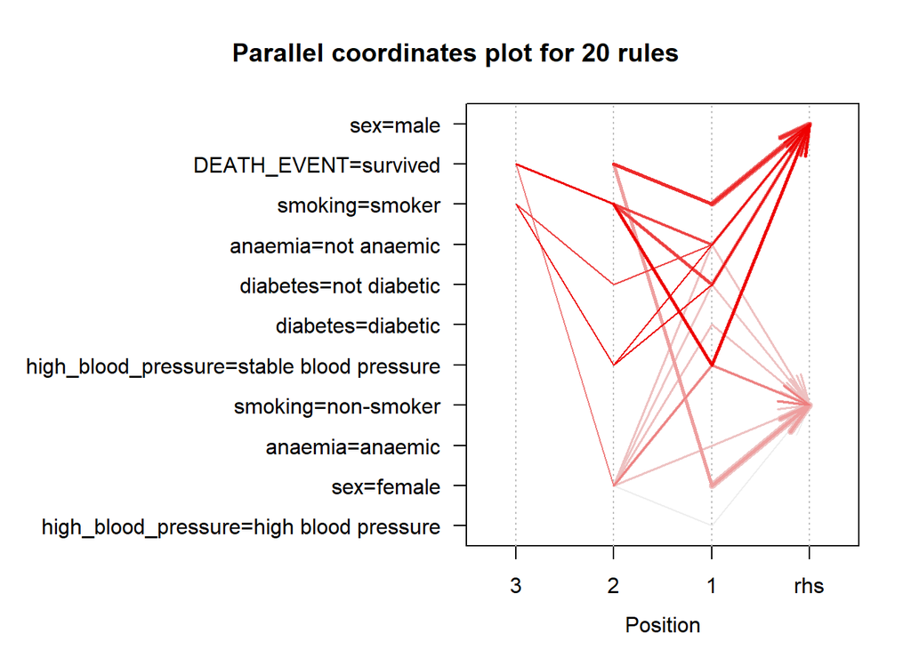

```r
plot(topRules, method = "paracoord")
```

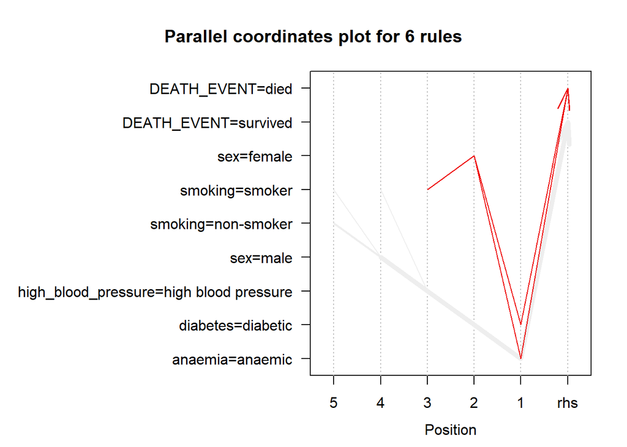

```r
plot(RHS, method="paracoord")
```